# TYK Solution for TAME 2.0 Module 4, Unsupervised Machine Learning

## TYK Questions

In the training module, we presented an unsupervised machine learning example that was based on defining *k*-means clusters based on chemical class where *k* = 2. Often times, analyses are conducted to explore potential clustering relationships without an preexisting idea of what *k* or the number of clusters should be. In this test your knowledge section, we’ll go through an example like that.

Using the accompanying flame retardant and pesticide physicochemical property variables found in the file (“Module5_4_TYKInput.csv”), answer the following questions:

## Solution

```r
library(pheatmap)
library(tidyverse)
library(factoextra)
```

#### Load and Organize Data for Pesticides and Flame Retardants (FR)

```r
# Pesticide and Flame Retardant data
chems <- read.csv("Module5_4_TYKInput.csv", fileEncoding = "UTF-8-BOM")
chems <- chems %>% column_to_rownames("CASRN")
colnames(chems)
```

```
##  [1] "List"
##  [2] "ATMOSPHERIC_HYDROXYLATION_RATE_.AOH._CM3.MOLECULE.SEC_OPERA_PRED"
##  [3] "BIOCONCENTRATION_FACTOR_OPERA_PRED"
##  [4] "BIODEGRADATION_HALF_LIFE_DAYS_DAYS_OPERA_PRED"
##  [5] "BOILING_POINT_DEGC_OPERA_PRED"
##  [6] "HENRYS_LAW_ATM.M3.MOLE_OPERA_PRED"
##  [7] "OPERA_KM_DAYS_OPERA_PRED"
##  [8] "OCTANOL_AIR_PARTITION_COEFF_LOGKOA_OPERA_PRED"
##  [9] "SOIL_ADSORPTION_COEFFICIENT_KOC_L.KG_OPERA_PRED"
## [10] "OCTANOL_WATER_PARTITION_LOGP_OPERA_PRED"
## [11] "MELTING_POINT_DEGC_OPERA_PRED"
## [12] "VAPOR_PRESSURE_MMHG_OPERA_PRED"
## [13] "WATER_SOLUBILITY_MOL.L_OPERA_PRED"
```

```r
head(chems)
```

```
##                  List
## 824-78-2   Pesticides
## 35153-18-5 Pesticides
## 34010-15-6 Pesticides
## 85977-73-7 Pesticides
## 593-50-0   Pesticides
## 35153-15-2 Pesticides
##            ATMOSPHERIC_HYDROXYLATION_RATE_.AOH._CM3.MOLECULE.SEC_OPERA_PRED
## 824-78-2                                                           1.16e-12
## 35153-18-5                                                         8.05e-11
## 34010-15-6                                                         8.05e-11
## 85977-73-7                                                         9.44e-11
## 593-50-0                                                           1.19e-11
## 35153-15-2                                                         8.05e-11
##            BIOCONCENTRATION_FACTOR_OPERA_PRED
## 824-78-2                              11.3561
## 35153-18-5                          1457.0300
## 34010-15-6                          1457.0300
## 85977-73-7                            32.1081
## 593-50-0                              54.7698
## 35153-15-2                           837.3490
##            BIODEGRADATION_HALF_LIFE_DAYS_DAYS_OPERA_PRED
## 824-78-2                                         4.09570
## 35153-18-5                                       5.34300
## 34010-15-6                                       5.34300
## 85977-73-7                                      50.42900
## 593-50-0                                       176.37000
## 35153-15-2                                       4.61624
##            BOILING_POINT_DEGC_OPERA_PRED HENRYS_LAW_ATM.M3.MOLE_OPERA_PRED
## 824-78-2                         278.910                          4.21e-10
## 35153-18-5                       295.795                          2.07e-05
## 34010-15-6                       295.795                          2.07e-05
## 85977-73-7                       407.827                          4.01e-09
## 593-50-0                         432.486                          5.48e-08
## 35153-15-2                       295.797                          2.07e-05
##            OPERA_KM_DAYS_OPERA_PRED
## 824-78-2                   0.251436
## 35153-18-5                 0.547640
## 34010-15-6                 0.547640
## 85977-73-7                 2.328360
```

[output cut: 22 more lines]

```
## 35153-15-2                                 5.58103
##            MELTING_POINT_DEGC_OPERA_PRED VAPOR_PRESSURE_MMHG_OPERA_PRED
## 824-78-2                         96.2665                       9.97e-05
## 35153-18-5                       23.3782                       9.57e-05
## 34010-15-6                       23.3782                       9.57e-05
## 85977-73-7                      143.8730                       9.54e-09
## 593-50-0                         87.6212                       9.51e-11
## 35153-15-2                       19.2008                       9.48e-05
##            WATER_SOLUBILITY_MOL.L_OPERA_PRED
## 824-78-2                         9.67929e-02
## 35153-18-5                       1.76000e-05
## 34010-15-6                       1.76000e-05
## 85977-73-7                       1.27000e-05
## 593-50-0                         9.79000e-08
## 35153-15-2                       1.11000e-05
```

```r
# Isolate just the physchem properties
props <- chems %>% select(!List)
colnames(props)
```

```
##  [1] "ATMOSPHERIC_HYDROXYLATION_RATE_.AOH._CM3.MOLECULE.SEC_OPERA_PRED"
##  [2] "BIOCONCENTRATION_FACTOR_OPERA_PRED"
##  [3] "BIODEGRADATION_HALF_LIFE_DAYS_DAYS_OPERA_PRED"
##  [4] "BOILING_POINT_DEGC_OPERA_PRED"
##  [5] "HENRYS_LAW_ATM.M3.MOLE_OPERA_PRED"
##  [6] "OPERA_KM_DAYS_OPERA_PRED"
##  [7] "OCTANOL_AIR_PARTITION_COEFF_LOGKOA_OPERA_PRED"
##  [8] "SOIL_ADSORPTION_COEFFICIENT_KOC_L.KG_OPERA_PRED"
##  [9] "OCTANOL_WATER_PARTITION_LOGP_OPERA_PRED"
## [10] "MELTING_POINT_DEGC_OPERA_PRED"
## [11] "VAPOR_PRESSURE_MMHG_OPERA_PRED"
## [12] "WATER_SOLUBILITY_MOL.L_OPERA_PRED"
```

```r
head(props)
```

```
##            ATMOSPHERIC_HYDROXYLATION_RATE_.AOH._CM3.MOLECULE.SEC_OPERA_PRED
## 824-78-2                                                           1.16e-12
## 35153-18-5                                                         8.05e-11
## 34010-15-6                                                         8.05e-11
## 85977-73-7                                                         9.44e-11
## 593-50-0                                                           1.19e-11
## 35153-15-2                                                         8.05e-11
##            BIOCONCENTRATION_FACTOR_OPERA_PRED
## 824-78-2                              11.3561
## 35153-18-5                          1457.0300
## 34010-15-6                          1457.0300
## 85977-73-7                            32.1081
## 593-50-0                              54.7698
## 35153-15-2                           837.3490
##            BIODEGRADATION_HALF_LIFE_DAYS_DAYS_OPERA_PRED
## 824-78-2                                         4.09570
## 35153-18-5                                       5.34300
## 34010-15-6                                       5.34300
## 85977-73-7                                      50.42900
## 593-50-0                                       176.37000
## 35153-15-2                                       4.61624
##            BOILING_POINT_DEGC_OPERA_PRED HENRYS_LAW_ATM.M3.MOLE_OPERA_PRED
## 824-78-2                         278.910                          4.21e-10
## 35153-18-5                       295.795                          2.07e-05
## 34010-15-6                       295.795                          2.07e-05
## 85977-73-7                       407.827                          4.01e-09
## 593-50-0                         432.486                          5.48e-08
## 35153-15-2                       295.797                          2.07e-05
##            OPERA_KM_DAYS_OPERA_PRED
## 824-78-2                   0.251436
## 35153-18-5                 0.547640
## 34010-15-6                 0.547640
## 85977-73-7                 2.328360
## 593-50-0                   0.622753
## 35153-15-2                 0.548048
##            OCTANOL_AIR_PARTITION_COEFF_LOGKOA_OPERA_PRED
## 824-78-2                                         6.11321
## 35153-18-5                                       9.08201
## 34010-15-6                                       9.08201
## 85977-73-7                                      10.76080
```

[output cut: 15 more lines]

```
## 35153-15-2                                 5.58103
##            MELTING_POINT_DEGC_OPERA_PRED VAPOR_PRESSURE_MMHG_OPERA_PRED
## 824-78-2                         96.2665                       9.97e-05
## 35153-18-5                       23.3782                       9.57e-05
## 34010-15-6                       23.3782                       9.57e-05
## 85977-73-7                      143.8730                       9.54e-09
## 593-50-0                         87.6212                       9.51e-11
## 35153-15-2                       19.2008                       9.48e-05
##            WATER_SOLUBILITY_MOL.L_OPERA_PRED
## 824-78-2                         9.67929e-02
## 35153-18-5                       1.76000e-05
## 34010-15-6                       1.76000e-05
## 85977-73-7                       1.27000e-05
## 593-50-0                         9.79000e-08
## 35153-15-2                       1.11000e-05
```

#### Plot original chemical properties as first look at data

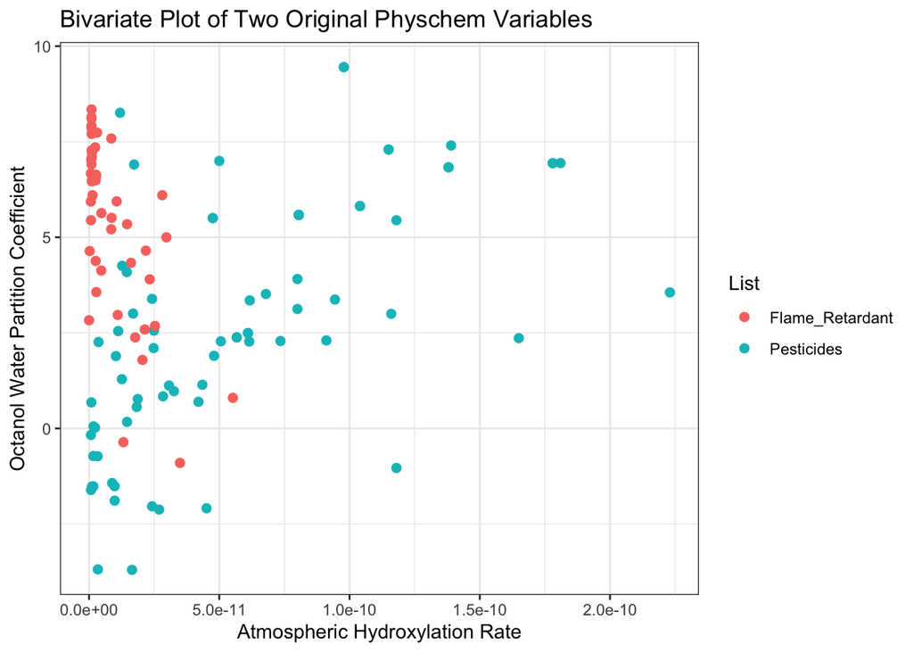

```r
ggplot(chems, aes(x = ATMOSPHERIC_HYDROXYLATION_RATE_.AOH._CM3.MOLECULE.SEC_OPERA_PRED, y = OCTANOL_WATER_PARTITION_LOGP_OPERA_PRED, color = List)) +
  geom_point(size = 2) + theme_bw() +
  ggtitle('Bivariate Plot of Two Original Physchem Variables') +
  xlab("Atmospheric Hydroxylation Rate") + ylab("Octanol Water Partition Coefficient")
```

Look at another set of properties

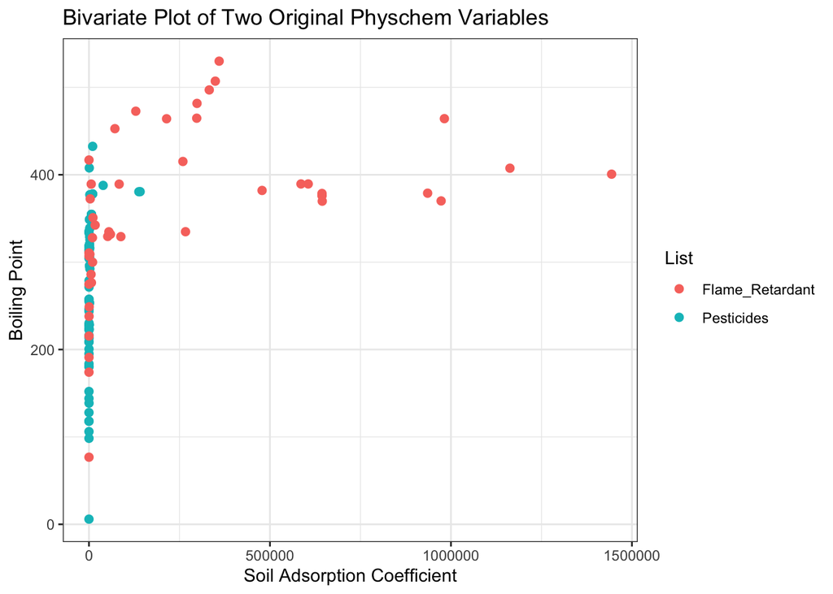

```r
ggplot(chems, aes(x = SOIL_ADSORPTION_COEFFICIENT_KOC_L.KG_OPERA_PRED, y = BOILING_POINT_DEGC_OPERA_PRED, color = List)) +
  geom_point(size = 2) + theme_bw() +
  ggtitle('Bivariate Plot of Two Original Physchem Variables') +
  xlab("Soil Adsorption Coefficient") + ylab("Boiling Point")
```

There are no clear associations when only looking at two variables at a time, so let’s proceed with running *k*-means.

### Question #1: What are some of the physicochemical properties that seem to be driving chemical clustering patterns derived through *k*-means?

Specify we are interested in 2 clusters

```r
num.centers <- 2
```

Run clustering analysis

```r
clusters <- kmeans(props,        # input dataframe
                   centers = num.centers,  # number of cluster centers to calculate
                   iter.max = 1000,        # the maximum number of iterations allowed
                   nstart = 50)            # number of rows used as the random set for the initial centers
```

Extract cluster assignments for the chemicals

```r
clusters$cluster
```

```
##    824-78-2  35153-18-5  34010-15-6  85977-73-7    593-50-0  35153-15-2
##           2           2           2           2           2           2
##    110-27-0    592-88-1     69-72-7 108175-15-1  67233-85-6    125-67-7
##           2           2           2           2           2           2
##  65733-20-2  42588-37-4  72962-43-7  52207-99-5  53042-79-8 146659-78-1
##           2           2           2           2           2           2
##   2465-59-0     57-50-1  86252-74-6  53120-26-6  53120-27-7    109-79-5
##           2           2           2           2           2           2
##     69-89-6    404-86-4    110-89-4     57-06-7  27519-02-4  35857-62-6
##           2           2           2           2           2           2
## 163041-94-9    137-32-6  74174-44-0  65733-16-6  40596-69-8     74-93-1
##           2           2           2           2           2           2
##     62-54-4     64-19-7     67-48-1 181213-09-2 123551-47-3  66410-28-4
##           2           2           2           2           2           2
##  66410-24-0    525-79-1     56-86-0   6766-87-6  15708-41-5    133-32-4
##           2           2           2           2           2           2
##   7681-93-8  34010-21-4    617-04-9     84-65-1   1193-18-6   5392-40-5
##           2           2           2           2           2           2
##  26532-24-1  26532-25-2     80-71-7  10519-33-2    623-19-8   3391-86-4
##           2           2           2           2           2           2
##   3687-48-7    824-39-5   6485-40-1   5870-93-9     79-33-4    814-80-2
##           2           2           2           2           2           2
##    106-22-9    112-12-9    119-36-8    106-24-1  26532-23-0    104-55-2
##           2           2           2           2           2           2
##     97-53-0    122-70-3  41318-75-6  39568-99-5    995-32-4   5945-33-5
##           2           2           1           2           2           2
## 437701-79-6 958802-46-5  67562-39-4  18181-70-9 147217-72-9 446254-39-3
##           2           1           2           2           2           1
##     87-83-2 446255-08-9 446254-32-6   1163-19-5  57117-31-4    106-41-2
##           2           1           1           2           2           2
## 446254-77-9     56-23-5 446254-51-9   2502-15-0   2227-13-6  20120-33-6
##           1           2           1           2           2           2
##  40321-76-4     82-68-8 446254-19-9  24173-07-7   2104-96-3  52434-59-0
##           1           2           1           2           2           2
##  77102-82-0 116995-32-5    813-78-5   6294-34-4  31454-48-5    118-79-6
##           1           1           2           2           2           2
##     93-52-7  53461-82-8 446255-54-5     78-40-0    147-82-0   1770-80-5
##           2           2           2           2           2           2
##  59080-39-6   5445-19-2  37853-59-1 115245-07-3 337513-68-5 446255-27-2
##           1           2           1           2           1           1
```

Aggregate results and prepare dataset for making a heatmap

```r
dat_wclusters <- as.data.frame(cbind(props,clusters$cluster))
colnames(dat_wclusters)[13] <- "kmeans_cluster"  # renaming this new column "kmeans_cluster"
dat_wclusters <- dat_wclusters[order(dat_wclusters$kmeans_cluster),]  # sorting data by cluster assignments
colnames(dat_wclusters)
```

```
##  [1] "ATMOSPHERIC_HYDROXYLATION_RATE_.AOH._CM3.MOLECULE.SEC_OPERA_PRED"
##  [2] "BIOCONCENTRATION_FACTOR_OPERA_PRED"
##  [3] "BIODEGRADATION_HALF_LIFE_DAYS_DAYS_OPERA_PRED"
##  [4] "BOILING_POINT_DEGC_OPERA_PRED"
##  [5] "HENRYS_LAW_ATM.M3.MOLE_OPERA_PRED"
##  [6] "OPERA_KM_DAYS_OPERA_PRED"
##  [7] "OCTANOL_AIR_PARTITION_COEFF_LOGKOA_OPERA_PRED"
##  [8] "SOIL_ADSORPTION_COEFFICIENT_KOC_L.KG_OPERA_PRED"
##  [9] "OCTANOL_WATER_PARTITION_LOGP_OPERA_PRED"
## [10] "MELTING_POINT_DEGC_OPERA_PRED"
## [11] "VAPOR_PRESSURE_MMHG_OPERA_PRED"
## [12] "WATER_SOLUBILITY_MOL.L_OPERA_PRED"
## [13] "kmeans_cluster"
```

```r
hm_cluster <- data.frame(dat_wclusters$kmeans_cluster, row.names = row.names(dat_wclusters))  # creating the dataframe to show which chemicals are assigned to which cluster for heatmap annotation bar
colnames(hm_cluster) <- "kmeans_cluster"   # reassigning the column name
hm_cluster$kmeans_cluster <- as.factor(hm_cluster$kmeans_cluster)   # coercing the cluster numbers into factor variables, to make the heat map prettier
head(hm_cluster)
```

```
##             kmeans_cluster
## 41318-75-6               1
## 958802-46-5              1
## 446254-39-3              1
## 446255-08-9              1
## 446254-32-6              1
## 446254-77-9              1
```

Make heatmap

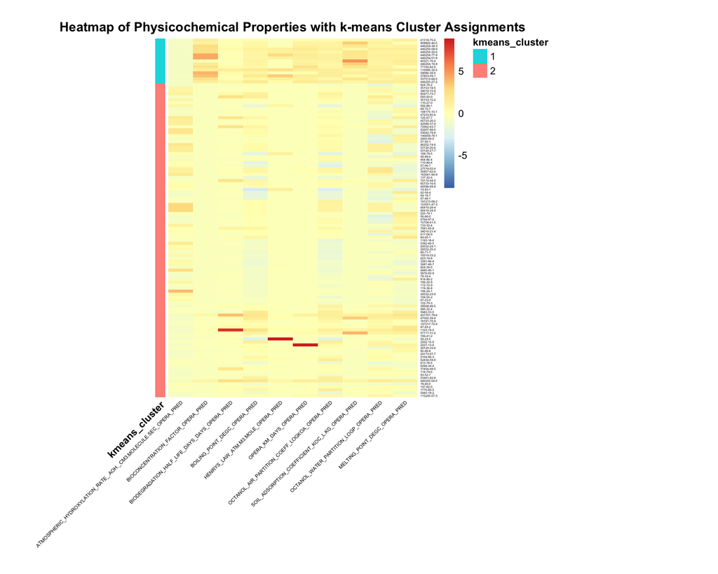

```r
chem_hm <- pheatmap(dat_wclusters[,1:10],
                    main = "Heatmap of Physicochemical Properties with k-means Cluster Assignments",
                    cluster_rows = FALSE, cluster_cols = FALSE,
                    scale = "column",
                    annotation_row = hm_cluster,
                    angle_col = 45, fontsize_col = 5, fontsize_row = 3,
                    cellheight = 3, cellwidth = 25,
                    border_color = FALSE
)
```

**Question #1**: What are some of the physicochemical properties that seem to be driving chemical clustering patterns derived through *k*-means?

**Answer**: Properties with values that show obvious differences between resulting clusters including atmospheric hydroxylation, bioconcentration factor, boiling point, and soil adsorption coefficient.

### Question 2: Upon reducing the data through PCA, which physicochemical property contributes the most towards informing data variance captured in the primary principal component?

```r
colnames(props) # review dataset of just physicochemical property data
```

```
##  [1] "ATMOSPHERIC_HYDROXYLATION_RATE_.AOH._CM3.MOLECULE.SEC_OPERA_PRED"
##  [2] "BIOCONCENTRATION_FACTOR_OPERA_PRED"
##  [3] "BIODEGRADATION_HALF_LIFE_DAYS_DAYS_OPERA_PRED"
##  [4] "BOILING_POINT_DEGC_OPERA_PRED"
##  [5] "HENRYS_LAW_ATM.M3.MOLE_OPERA_PRED"
##  [6] "OPERA_KM_DAYS_OPERA_PRED"
##  [7] "OCTANOL_AIR_PARTITION_COEFF_LOGKOA_OPERA_PRED"
##  [8] "SOIL_ADSORPTION_COEFFICIENT_KOC_L.KG_OPERA_PRED"
##  [9] "OCTANOL_WATER_PARTITION_LOGP_OPERA_PRED"
## [10] "MELTING_POINT_DEGC_OPERA_PRED"
## [11] "VAPOR_PRESSURE_MMHG_OPERA_PRED"
## [12] "WATER_SOLUBILITY_MOL.L_OPERA_PRED"
```

```r
my.pca <- prcomp(props,   # input dataframe of physchem data
                   scale = TRUE, center = TRUE) # scaling and centering data
```

Looking at how much of the variance was able to be compressed into the eigenvectors

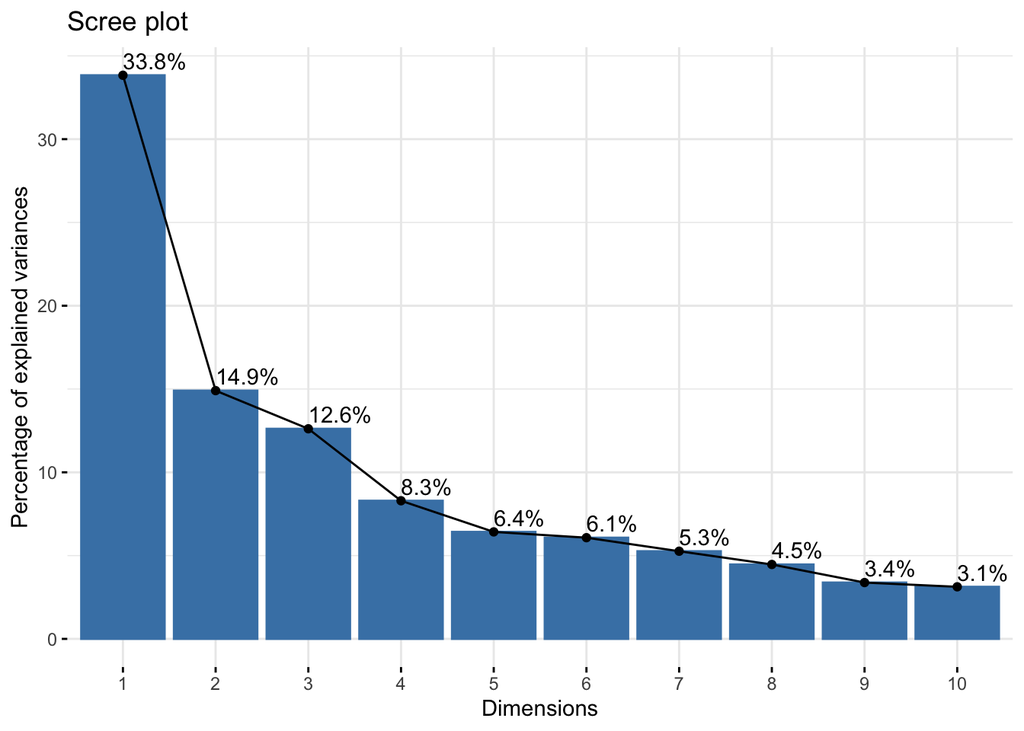

```r
fviz_eig(my.pca, addlabels = TRUE)
```

View scores for each chemical’s contribution towards each principal component

```r
head(my.pca$x)
```

```
##                   PC1        PC2        PC3         PC4          PC5        PC6
## 824-78-2    1.2720386  0.7993619 -0.8859957 -0.09170176 -0.182501483  1.1345009
## 35153-18-5  0.4146144 -1.3160292  0.3468088  0.16503493  0.003800121 -0.1995244
## 34010-15-6  0.4146144 -1.3160292  0.3468088  0.16503493  0.003800121 -0.1995244
## 85977-73-7 -0.6596662 -1.3818123 -0.7382862 -0.58803576 -0.044769956 -0.2296619
## 593-50-0   -1.7518465 -1.0354340 -0.6321390 -1.92362474 -0.054287634 -0.8113924
## 35153-15-2  0.4312503 -1.3267284  0.3641146  0.17740535  0.004977330 -0.1986844
##                   PC7         PC8        PC9        PC10        PC11       PC12
## 824-78-2   -0.1936257 -0.02909379  0.2475488 -0.26563889 -0.30270435  0.4415762
## 35153-18-5  0.1099087  0.12664840 -0.2025996  0.07655025  0.11183257 -0.2515270
## 34010-15-6  0.1099087  0.12664840 -0.2025996  0.07655025  0.11183257 -0.2515270
## 85977-73-7  0.2142958  1.01303848  0.2954191  0.08946171 -0.16809808  0.1422101
## 593-50-0   -0.4533767 -1.01483359 -1.0024788 -0.18189765  0.13388982  0.1124860
## 35153-15-2  0.1093781  0.11711288 -0.2166496  0.07532488  0.08883698 -0.2454929
```

View loadings

```r
my.pca$rotation
```

```
##                                                                          PC1
## ATMOSPHERIC_HYDROXYLATION_RATE_.AOH._CM3.MOLECULE.SEC_OPERA_PRED  0.13870268
## BIOCONCENTRATION_FACTOR_OPERA_PRED                               -0.32807699
## BIODEGRADATION_HALF_LIFE_DAYS_DAYS_OPERA_PRED                    -0.24938256
## BOILING_POINT_DEGC_OPERA_PRED                                    -0.43598823
## HENRYS_LAW_ATM.M3.MOLE_OPERA_PRED                                -0.08196541
## OPERA_KM_DAYS_OPERA_PRED                                         -0.28391705
## OCTANOL_AIR_PARTITION_COEFF_LOGKOA_OPERA_PRED                    -0.41146016
## SOIL_ADSORPTION_COEFFICIENT_KOC_L.KG_OPERA_PRED                  -0.34498189
## OCTANOL_WATER_PARTITION_LOGP_OPERA_PRED                          -0.32036549
## MELTING_POINT_DEGC_OPERA_PRED                                    -0.31867775
## VAPOR_PRESSURE_MMHG_OPERA_PRED                                    0.12260538
## WATER_SOLUBILITY_MOL.L_OPERA_PRED                                 0.16121053
##                                                                          PC2
## ATMOSPHERIC_HYDROXYLATION_RATE_.AOH._CM3.MOLECULE.SEC_OPERA_PRED -0.54491237
## BIOCONCENTRATION_FACTOR_OPERA_PRED                                0.24773530
## BIODEGRADATION_HALF_LIFE_DAYS_DAYS_OPERA_PRED                     0.02035876
## BOILING_POINT_DEGC_OPERA_PRED                                    -0.24479821
## HENRYS_LAW_ATM.M3.MOLE_OPERA_PRED                                 0.31959054
## OPERA_KM_DAYS_OPERA_PRED                                          0.18529242
## OCTANOL_AIR_PARTITION_COEFF_LOGKOA_OPERA_PRED                    -0.25290894
## SOIL_ADSORPTION_COEFFICIENT_KOC_L.KG_OPERA_PRED                   0.19163119
## OCTANOL_WATER_PARTITION_LOGP_OPERA_PRED                          -0.30203309
## MELTING_POINT_DEGC_OPERA_PRED                                     0.26999441
## VAPOR_PRESSURE_MMHG_OPERA_PRED                                    0.21481548
## WATER_SOLUBILITY_MOL.L_OPERA_PRED                                 0.36596939
##                                                                         PC3
## ATMOSPHERIC_HYDROXYLATION_RATE_.AOH._CM3.MOLECULE.SEC_OPERA_PRED  0.1843611
## BIOCONCENTRATION_FACTOR_OPERA_PRED                                0.2645075
## BIODEGRADATION_HALF_LIFE_DAYS_DAYS_OPERA_PRED                    -0.1720651
## BOILING_POINT_DEGC_OPERA_PRED                                    -0.1650783
## HENRYS_LAW_ATM.M3.MOLE_OPERA_PRED                                 0.4690177
## OPERA_KM_DAYS_OPERA_PRED                                          0.1887648
## OCTANOL_AIR_PARTITION_COEFF_LOGKOA_OPERA_PRED                    -0.1467527
## SOIL_ADSORPTION_COEFFICIENT_KOC_L.KG_OPERA_PRED                   0.1109221
## OCTANOL_WATER_PARTITION_LOGP_OPERA_PRED                           0.3682170
## MELTING_POINT_DEGC_OPERA_PRED                                    -0.4163084
## VAPOR_PRESSURE_MMHG_OPERA_PRED                                    0.3951818
## WATER_SOLUBILITY_MOL.L_OPERA_PRED                                -0.2909889
##                                                                           PC4
```

[output cut: 101 more lines]

```
## VAPOR_PRESSURE_MMHG_OPERA_PRED                                    0.016204966
## WATER_SOLUBILITY_MOL.L_OPERA_PRED                                -0.049629740
##                                                                         PC12
## ATMOSPHERIC_HYDROXYLATION_RATE_.AOH._CM3.MOLECULE.SEC_OPERA_PRED  0.01530031
## BIOCONCENTRATION_FACTOR_OPERA_PRED                                0.03085355
## BIODEGRADATION_HALF_LIFE_DAYS_DAYS_OPERA_PRED                    -0.10421563
## BOILING_POINT_DEGC_OPERA_PRED                                     0.78813989
## HENRYS_LAW_ATM.M3.MOLE_OPERA_PRED                                 0.02598819
## OPERA_KM_DAYS_OPERA_PRED                                          0.01208546
## OCTANOL_AIR_PARTITION_COEFF_LOGKOA_OPERA_PRED                    -0.57557290
## SOIL_ADSORPTION_COEFFICIENT_KOC_L.KG_OPERA_PRED                  -0.00868479
## OCTANOL_WATER_PARTITION_LOGP_OPERA_PRED                          -0.10957809
## MELTING_POINT_DEGC_OPERA_PRED                                    -0.11732704
## VAPOR_PRESSURE_MMHG_OPERA_PRED                                    0.04670464
## WATER_SOLUBILITY_MOL.L_OPERA_PRED                                 0.08156726
```

**Question 2**: Upon reducing the data through PCA, which physicochemical property contributes the most towards informing data variance captured in the primary principal component?

**Answer**: Boiling point contributes the most towards principal component #1, as it has the largest magnitude (-0.436).

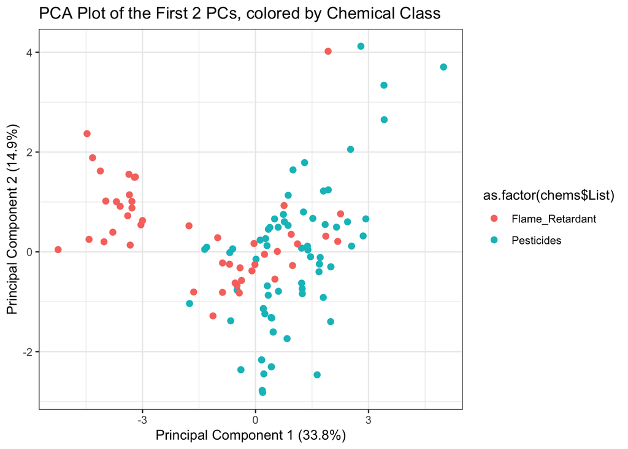

```r
# Original chemical class coloring
ggplot(as.data.frame(my.pca$x), aes(x = PC1, y = PC2, color = as.factor(chems$List))) +
  geom_point(size = 2) +
  theme_bw() +
  ggtitle('PCA Plot of the First 2 PCs, colored by Chemical Class') +
  xlab("Principal Component 1 (33.8%)") + ylab("Principal Component 2 (14.9%)")
```

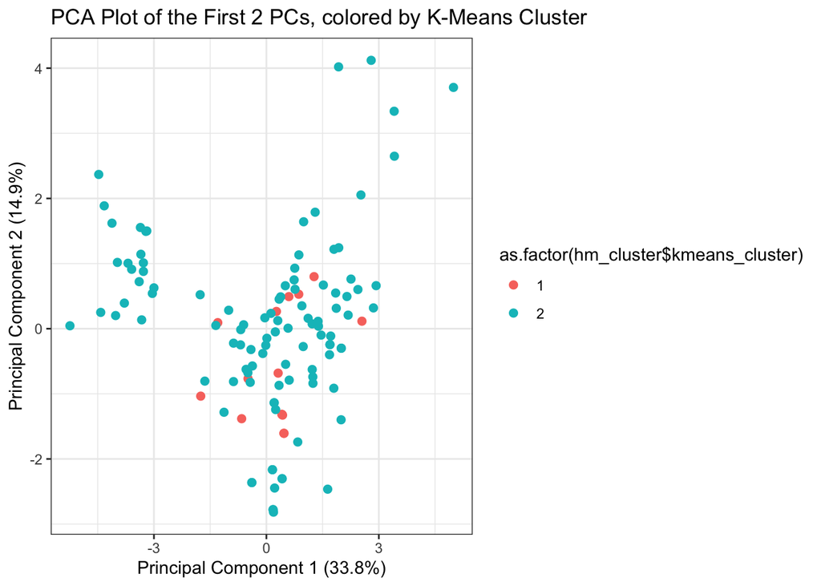

```r
# K means clusters
ggplot(as.data.frame(my.pca$x), aes(x = PC1, y = PC2, color = as.factor(hm_cluster$kmeans_cluster))) +
  geom_point(size = 2) +
  theme_bw() +
  ggtitle('PCA Plot of the First 2 PCs, colored by K-Means Cluster') +
  xlab("Principal Component 1 (33.8%)") + ylab("Principal Component 2 (14.9%)")
```

**Answer**: Based on the figures, the *k*-means clusters did not align with the chemical classes. This could potentially be attributed to PCA only capturing about 50% of the variance from the original dataset, omitting useful data that could have helped the *k*-means more closely align with the chemical classes.